# Problem Set 4 Solutions

# Question 1 (20 points)

Suppose that a stock price $S$ folows geometric Brownian motion with expected reutrn $\mu$ and volatility $\sigma$. What is the process followed by the variable $\sqrt{S}$?

#### Solution:

Let $G = \sqrt{S}$. By Ito’s Lemma,
$$\begin{align}
dG = \left( \frac{\partial G}{\partial S}\mu S + \frac{\partial G}{\partial t} + \frac{1}{2} \frac{\partial^{2}G}{\partial S^{2}}\sigma^{2}S^{2} \right)dt + \frac{\partial G}{\partial S} \sigma S dZ.
\end{align}$$
Since $\frac{\partial G}{\partial S} = \frac{1}{2}S^{-\frac{1}{2}}$, $\frac{\partial G}{\partial t}=0$, and $\frac{\partial^{2}G}{\partial S^{2}} = -\frac{1}{4}S^{-\frac{3}{2}}$,
$$\begin{align}
dG = \frac{1}{2}G \left(\mu - \frac{1}{4}\sigma^{2} \right) dt + \frac{1}{2}\sigma GdZ.
\end{align}$$

# Question 2 (20 points)

Show that the Black-Scholes formulas for call and put options satisfy put-call parity. (Hint: you only need to use the formulas to verify put-call parity).

#### Solution:

By the formulas,
$$\begin{align}
C-P = S_{0}(\Phi(d_{1}) + \Phi(-d_{1})) - Xe^{-rT}(\Phi(d_{2}) + \Phi(-d_{2})).
\end{align}$$
Since $\Phi(-d) = 1-\Phi(d)$,
$$\begin{align}
C-P = S_{0} - Xe^{-rT}.
\end{align}$$

By rewriting this, we get $S_{0}+p = c+Xe^{-rT}$, which is the put-call parity relationship.

# Question 3 (20 points)

What is the price of a European put option on a non-dividend-paying stock when the stock price is $69, the strike price is $70, the risk-free interest rate is 5% per annum, the volatility is 35% per annum, and the time to maturity is six months?

#### Solution:

Given the information,
$$\begin{align}
&d_{1} = \frac{\ln(69/70)+(0.05+0.35^{2}/2)\times 0.5}{0.35\sqrt{0.5}} = 0.1666 \\
&d_{2} = d_{1} - 0.35\sqrt{0.5} = -0.0809.
\end{align}$$
Thus, the price of European put is
$$\begin{align}
70e^{-0.05\times0.5}N(0.0809) -69N(-0.1666) = 70e^{-0.025}\times 0.5323 -69\times 0.4338= 6.4.
\end{align}$$

# Question 4 (20 points)

Let $f$ be the price of a call option. Supose that $rf> \frac{\partial f}{\partial t} + \frac{\partial f}{\partial S}rS + \frac{1}{2}\frac{\partial^{2}f}{\partial S^{2}}\sigma^{2}S^{2}$, which means that the BSM differential equation does not hold. Explain how you can exploit the arbitrage opportunity over period $dt$.

#### Solution:

# Question 5 (20 points)

Download the VIX options data posted on the course website, `vixOptionsData.csv`. The data consists of options prices for VIX call and put options on May 29, 2018, with an expiration for the following day, May 30, 2018 (e.g. $T=1/252$). Assume that the continuously-compounded risk-free rate is $r_f = 0.019$ and that the closing value of the VIX index on May 29th was $S_0 = 17.02$. Using this information, compute the Black-Scholes-Merton implied volatility for each put option with strike $X < S_0$ and for each call option with strike $X > S_0$. Plot the implied volatilities as a function of the strikes on a single plot (calls and puts together). Note: due to discreteness of pricing, some of the implied volatilities will be spuriously large – above 0.98. Plot only the implied vols that are less than 0.98.

#### Solution:

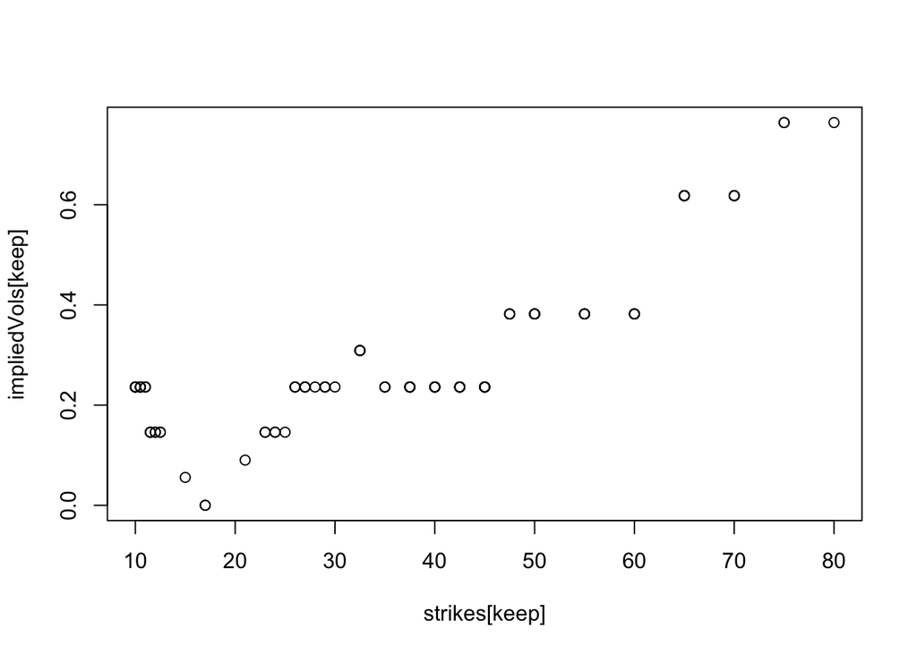

```r
# Data
S0 = 17.02
rf = 0.019
tt = 1/252
vixData = read.csv('vixOptionsData.csv')
callData = vixData[vixData$option_type=='c',]
putData = vixData[vixData$option_type=='p',]
callDataKeep = callData[callData$strike>S0,]
putDataKeep = putData[putData$strike<S0,]
bsError = function(sigma,price,S0,K,rf,tt,type=c('call','put')){
  d1 = (log(S0/K) + (rf+(sigma^2)/2)*tt)/(sigma*sqrt(tt))
  d2 = d1 - sigma*sqrt(tt)
  if(type=='call'){
    bsPrice = S0*pnorm(d1) - K*exp(-rf*tt)*pnorm(d2)
  } else if(type=='put'){
    bsPrice = K*exp(-rf*tt)*pnorm(-d2) - S0*pnorm(-d1)
  }
  return((price - bsPrice)^2)
}
bsImpliedVol = function(price,S0,K,rf,tt,type=c('call','put')){
  out = optimize(f=bsError, interval=c(0,1),price=price,S0=S0,K=K, rf=rf, tt=tt, type=type)
  return(out$minimum)
}

nCalls = dim(callDataKeep)[1]
nPuts = dim(putDataKeep)[1]
callImpliedVols = rep(NA,nCalls)
putImpliedVols = rep(NA,nPuts)
for(ix in 1:nCalls){
  callImpliedVols[ix] = bsImpliedVol(callDataKeep$close[ix],S0,callDataKeep$strike[ix],rf,tt,'call')
}
for(ix in 1:nPuts){
  putImpliedVols[ix] = bsImpliedVol(putDataKeep$close[ix],S0,putDataKeep$strike[ix],rf,tt,'put')
}
strikes = c(putDataKeep$strike,callDataKeep$strike)
impliedVols = c(putImpliedVols,callImpliedVols)
keep = impliedVols < 0.98
plot(strikes[keep],impliedVols[keep])
```